# HW 3

## 1.2

Notice that the above decision boundary is decidedly non-linear. It seems to perform reasonably well, but there are indeed some misclassifications. Let’s see if increasing the cost [^1] helps our classification error rate. Refit the svm with the radial kernel, $\gamma=1$, and a cost of 10000. Plot this svm on the training data.

```r
# Fit SVM with cost of 10000
svmfit = svm(y~., data = dat_train, kernel = "radial", cost = 10000, gamma = 1, scale = FALSE)
print(svmfit)
```

```
##
## Call:
## svm(formula = y ~ ., data = dat_train, kernel = "radial", cost = 10000,
##     gamma = 1, scale = FALSE)
##
##
## Parameters:
##    SVM-Type:  C-classification
##  SVM-Kernel:  radial
##        cost:  10000
##
## Number of Support Vectors:  30
```

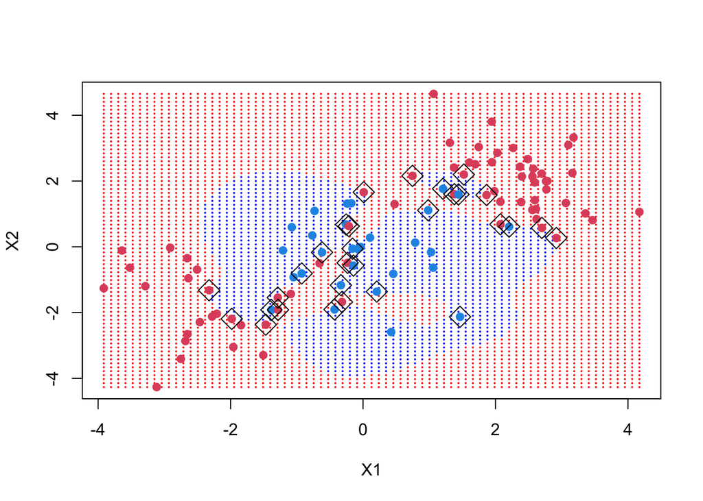

```r
xgrid = make.grid(x_train)

# Overlay prediction on the grid
ygrid = predict(svmfit, xgrid)
plot(xgrid, col = c("red","blue")[as.numeric(ygrid)], pch = 20, cex = .2)
points(x_train, col = y_train*2, pch = 19)
points(x_train[svmfit$index,], pch = 5, cex = 2)
```

## 1.3

It would appear that we are better capturing the training data, but comment on the dangers (if any exist), of such a model.

This model is overfit. The primary danger of overfitting a model is the decrease in the generalizability of the model. Since it is overly fit to the noise in the training set, it will likely not be able to make accurate predictions on a testing data set.

## 1.4

Create a confusion matrix by using this svm to predict on the current testing partition. Comment on the confusion matrix. Is there any disparity in our classification results?

```r
table(true=y_test, pred=predict(svmfit, newdata=dat_test))
```

```
##     pred
## true  1  2
##    1 62 17
##    2  3 18
```

There does seems to be a disparity in the classifications as shown in the confusion matrix. Observations in class 1 were much more likely to be misclassified as class 2 than observations in class 2 were to be misclassified as class 1. Respectively, 17/79 = 21.5% of points in class 1 were misclassified, and 3/21 = 14.3% of points in class 2 were misclassified.

## 1.5

Is this disparity because of imbalance in the training/testing partition? Find the proportion of class `2` in your training partition and see if it is broadly representative of the underlying 25% of class 2 in the data as a whole.

```r
table(y_train)
```

```
## y_train
##  1  2
## 71 29
```

It looks like 29% of the training dataset is of class 2. This is not too far off from the general 25% of class 2 in the data as a whole. Although a non representative training data set can cause a disparity, this proportion seems acceptable, and the misclassification could instead be due to overfitting of the model, rather than a non-representative training dataset.